# Final_Assignment_AEA1

| Name | examnr. |
| --- | --- |
| Daniela Petrova | u1263320 |
| Jan Willem Tempelaar | u1261325 |

## Motivation

A good economic state relates to a low unemployment rate. Besides, a good economic state allows a government to execute particular policies to maintain a low unemployment rate and offer financial support to the unemployed. A low level of unemployment could imply a relative high level of wealth. Having a relative high level of wealth, intuitively, gives less reason to complain about individuals and institutions facilitating the wealth. This observation seems to point at a somewhat obvious relationship between economic state and trust. Bac (2008) hypotheses this correlation between wealth and trust and finds empirical evidence that a higher average level of trust is found in countries with higher average level of wealth.

In the wake the financial crisis wealth of most European citizen declined in financial terms. After the crisis some wealth indicators, such as investments, unemployment and purchasing power worsened. Using budgetary expansion and monetary policies European governments tried to change the decreasing patterns, however, the effects of these policies were not visible immediately. Roth (2009) researched the effect of the financial crisis on institutional trust, in particular the trust in institutions of the European Union. He found empirical evidence that after the financial crisis the trust EU’s institutions fell significantly.

Assuming the correlation between wealth and trust, this research tries to estimate empirically the effect of the financial crisis on the level of trust in European countries. Following the results of previous research, we predict that the financial crisis had a visible negative effect on the level of trust in European countries. In his research, Roth (2009) mainly focuses on the effect of the financial crisis on institutional trust. In our research we want to provide a more general view on trust so we distinguish between different types of trust, such as the defined by CBS trust in others, the legal system, the police, the Parliament, political parties, the European Parliament and the United Nations.

"How a lack of trust in government explains Brexit vote"

Video source

```python
from IPython.display import YouTubeVideo
YouTubeVideo("QKfZ4qUmEV0")
```

[video not shown]

## Method

After comparing various data sources we decided to use data from the CBS StatLine (2017)(Centraal Bureau voor de Statistiek). Data is provided for most countries in Europe from 2002 to 2014 and the data is biannual. The financial crisis started in 2008, so, the data time period is relatively short but provides the possibility to see a trend before and after the crisis with possible (negative) peaks visible in 2010.

We aim to compare the levels of trust in others and in institutions in different periods. However, the data, as provided by CBS StatLine (2017) has some missing information for some countries in particular years which imposes a constraint on our work. Therefore, we clean the data and only use a full version of 13 European countries for the period 2002-2014. The complete data set of CBS StatLine (2017) includes scores ("the evaluation of trust") and percentages ("the percentage of people with trust in") for evaluation of trust in different variables, which are defined as follows: "Evaluation of trust in - Trust in other people and in a number of political and organisational institutions in terms of a mark from 0 to 10, where 0 equals no trust at all and 10 equals complete trust."

"Percentage of people with trust in - The percentage of people assigning a score of 6 or higher in answer to the questions about trust in other people and a number of political and organisational institutions, where 0 means no trust at all and 10 means complete trust."

In our research we focus on scores only, because we are interested in the trend in average trust,rather than the percentage of people with a certain level of trust.

Rather than following the example set in the research by Roth (2009), where the focus is on the effect of the financial crisis on institutional trust, in our research we look at three different trust scores: Evaluation of trust in Other people, Parliament and European Parliament. We compare the scores for the Netherlands and the United Kingdom (level comparison) and for each of the two separately, to chack for change of these scores in time. In addition, we provide a visual representation of these results. We chose to do our analysis for the Netherlads as a home state and the United Kingdom, because of potentially intriguing results due to the financial crisis in 2008 and preceding changes in trust levels before BrExit. We chose to focus on trust in others, trust in the Parliament and trust in the European Parliament as these variables can intuitively be related to these events - we expect a sudden decline in the score of trust in the Parliament right after the financial crisis for both the Netherlands and the United Kingdom and a decline in the score of trust in the European Parliament for the United Kingdom for the last available period, preceding Brexit. Obviously, there are many factors that play a role in determining trust levels, which prevent us from determining any causality and it is crucial to note that this is not the aim of our research. Rather, we focus on the evolution of trust in the variables mentioned above and look for a general relationship between our results with these events.

The level comparison for the evaluation of trust is measured as:

*Difference in trust score = (Evaluation of trust in $Variable_i$ for $year_j$) - (Evaluation of trust in $Variable_i$ for 2002)*

where j is an year from 2004-2014.

The execution is structured as follows. First, we provide a general view on the data. Second, we select our two countries of interest. Third, we provide some graphs for the two countries on the selected variables. Then, we determine the change in the evaluation scores per variable per country and present our results in graphs.

## Answer and Discussion

To start with, we see from the table showing the scores for the Netherlands and the United Kingdom that there is no difference in the evolution of trust in others between the two countries at first sight - both have increased their evaluation by 0.3 points from 2002 to 2014 in total. Figure 1.1. presents the evolution of trust in other people, the Parliament and the European Parliament for the Netherlands for the period 2002-2014. In the graph it can be seen that the evaluation score for trust in others has remained fairly constant. However, trust in the European Parliament (EP) shows a sudden decline in 2006 and recovers later. The exact opposite holds for the score of trust in the EP fot the United Kingdom - there is a sudden rise in the score for 2006 and later on it decreases to even lower than the initial level, as shown in Figure 1.2.. Nonetheless, the score for trust in other people for the United Kingdom also remains fairly constant at a level above the score for the EP or the Parliament.

Figures 2, 3, and 4 give an overview of trust levels in the Netherlands, while figures 5, 6 and 7 give an overview of trust levels in the United Kingdom. We first compare Figure 2. and Figure 5.. The trust in others has slightly increased in the Netherlands over the early period and remained at the higher level in later years. The data shows a relative jump in trust in others in 2004 and 2008 compared to 2002. No drop in trust is visible around 2010. Similar to the Netherlands, the change in the scores for trust in others shows a slight increase over the years measured, although the score remains below the level for the Netherlands.

Secondly, we consider the changes in scores for trust in the countries' parliaments, as presented by Figure 3. for the Netherlands and Figure 6. for the United Kingdom. The data on trust in the Dutch Parliament shows a slightly increasing pattern prior to the crisis, and a slightly decreasing pattern after the crisis. Both the trust in the British Parliament (Figure 6.) and the European Parliament (Figure 7.) show a decrease in 2010. However, the decrease is marginal compared to years other than when the financial crisis started, hence no clear effect is visible. From Figure 7. it can be seen that within the United Kingdom, trust in the European Parliament is fluctuating a lot, yet, no clear pattern is visible. As cen be seen from Figure 4., the levels of trust in the European Parliament within the Netherlands show a sudden drop in 2006 and are restored to a similar to the initial level from 2002 later on with little fluctuations.

To summarize these results, we see little if any difference between the levels of trust in other people in the two countries. We observe sudden (negative for the Netherlands and positive for the United Kingdom) peaks prior to the year of the financial crisis and stabilisation to a less volatile pattern later on for the trust in the European Parliament. The graphs for both countries show a slowly decreasing trend for the trust in the European Parliament after 2008, where the level for the United Kingdom remains below this for the Netherlands, possibly showing the early signs of doubt preceding Brexit. Nevertheless, since the differences in scores during the financial crisis are marginal relative to the other differences over the years, comparison between the Netherlands and the United Kingdom on the change in trust levels after the crisis is questionable.

## Execution

### Loading the data

We use data from CBS StatLine from 15th June 2017: Trust in others, legal system and politics; European comparison

```python
# First we clear all previous python imports and variables by resetting the python kernel.
# We load the edited dataset using only scores
%reset -f


import pandas as pd
#importing packages
import numpy as np
import pandas as pd
from scipy import arange, optimize
import matplotlib.pyplot as plt
%matplotlib inline

import plotly.plotly as py
import plotly.graph_objs as go


df_trust = pd.read_csv('Trust_in_others_law_170118125214.csv', sep = ',')


%matplotlib inline
```

```python
df_trust.fillna(method='ffill', inplace=True)
df_trust.set_index('Countries', inplace=True)
df_trust.Periods = pd.to_datetime(df_trust.Periods, format="%Y")
df_trust.head(14)
#for a general look at the data
```

| Countries | Periods | Other people | Legal system | Police | Politicians | Parliament | Political parties | European Parliament | United Nations |
| --- | --- | --- | --- | --- | --- | --- | --- | --- | --- |
| Denmark | 2002-01-01 | 7.0 | 7.1 | 7.9 | 5.5 | 6.2 | . | 4.8 | 6.5 |
| Denmark | 2004-01-01 | 6.8 | 7.2 | 7.9 | 5.6 | 6.3 | 5.6 | 4.8 | 6.6 |
| Denmark | 2006-01-01 | 7.0 | 7.5 | 7.8 | 5.6 | 6.4 | 4.8 | 4.8 | 5.4 |
| Denmark | 2008-01-01 | 6.9 | 7.3 | 7.6 | 5.6 | 6.5 | 5.7 | 5.0 | 6.5 |
| Denmark | 2010-01-01 | 6.8 | 7.4 | 7.7 | 5.0 | 5.8 | 5.2 | 5.0 | 6.2 |
| Denmark | 2012-01-01 | 7.0 | 7.7 | 8.0 | 5.2 | 6.1 | 5.3 | 5.2 | 6.6 |
| Denmark | 2014-01-01 | 6.9 | 7.4 | 7.7 | 4.9 | 5.9 | 5.1 | 4.8 | 6.3 |
| Germany | 2002-01-01 | 4.7 | 5.7 | 6.7 | 3.5 | 4.5 | . | 4.5 | 5.2 |
| Germany | 2004-01-01 | 4.8 | 5.5 | 6.5 | 3.2 | 4.2 | 3.2 | 4.2 | 4.9 |
| Germany | 2006-01-01 | 4.8 | 5.6 | 6.6 | 3.3 | 4.2 | 3.3 | 4.1 | 4.7 |
| Germany | 2008-01-01 | 4.9 | 5.8 | 6.8 | 3.5 | 4.7 | 3.5 | 4.3 | 5.0 |
| Germany | 2010-01-01 | 4.7 | 5.7 | 6.9 | 3.4 | 4.3 | 3.4 | 4.0 | 4.7 |
| Germany | 2012-01-01 | 5.0 | 6.0 | 6.9 | 3.8 | 4.9 | 3.8 | 4.4 | 5.1 |
| Germany | 2014-01-01 | 5.1 | 5.2 | 6.7 | 3.1 | 3.6 | 2.9 | 4.4 | 5.5 |

```python
df_trust.dtypes
```

```
Periods                datetime64[ns]
Other people                  float64
Legal system                  float64
Police                        float64
Politicians                   float64
Parliament                    float64
Political parties              object
European Parliament           float64
United Nations                float64
dtype: object
```

```python
# A summary for the Netherlands and the United Kingdom
df_trust.loc[((df_trust.index == 'The Netherlands')|(df_trust.index == 'United Kingdom')) & ((df_trust['Periods'] == '2002-01-01')|(df_trust['Periods'] == '2014-01-01'))]
```

| Countries | Periods | Other people | Legal system | Police | Politicians | Parliament | Political parties | European Parliament | United Nations |
| --- | --- | --- | --- | --- | --- | --- | --- | --- | --- |
| The Netherlands | 2002-01-01 | 5.7 | 5.4 | 5.8 | 4.9 | 5.2 | . | 4.7 | 5.4 |
| The Netherlands | 2014-01-01 | 6.0 | 6.0 | 6.4 | 4.9 | 5.2 | 4.9 | 4.5 | 5.5 |
| United Kingdom | 2002-01-01 | 5.1 | 5.0 | 6.0 | 3.8 | 4.7 | . | 3.6 | 5.3 |
| United Kingdom | 2014-01-01 | 5.4 | 5.6 | 6.3 | 3.5 | 4.3 | 3.5 | 3.1 | 4.9 |

```python
dfNL = df_trust[['Periods', 'Other people' , 'Parliament', 'European Parliament']].loc[df_trust.index=='The Netherlands']
dfNL
```

| Countries | Periods | Other people | Parliament | European Parliament |
| --- | --- | --- | --- | --- |
| The Netherlands | 2002-01-01 | 5.7 | 5.2 | 4.7 |
| The Netherlands | 2004-01-01 | 5.8 | 4.7 | 4.6 |
| The Netherlands | 2006-01-01 | 5.8 | 5.3 | 3.5 |
| The Netherlands | 2008-01-01 | 6.0 | 5.6 | 5.1 |
| The Netherlands | 2010-01-01 | 6.0 | 5.4 | 4.9 |
| The Netherlands | 2012-01-01 | 6.0 | 5.3 | 4.8 |
| The Netherlands | 2014-01-01 | 6.0 | 5.2 | 4.5 |

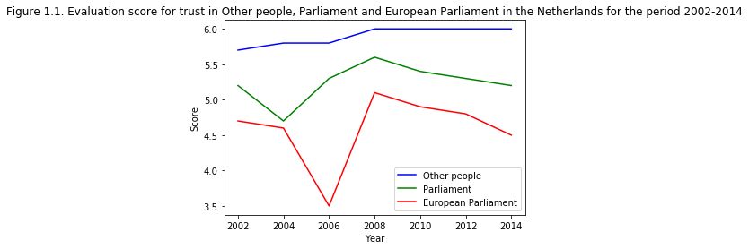

```python
plt.plot(dfNL.Periods, dfNL['Other people'], color='b')
plt.plot(dfNL.Periods, dfNL['Parliament'], color='g')
plt.plot(dfNL.Periods, dfNL['European Parliament'], color='r')
plt.xlabel('Year')
plt.ylabel('Score')
plt.legend()
plt.title('Figure 1.1. Evaluation score for trust in Other people, Parliament and European Parliament in the Netherlands for the period 2002-2014')
plt.show()
```

Back to Answer and Discussion

```python
dfGB = df_trust[['Periods', 'Other people', 'Parliament', 'European Parliament']].loc[df_trust.index=='United Kingdom']
dfGB
```

| Countries | Periods | Other people | Parliament | European Parliament |
| --- | --- | --- | --- | --- |
| United Kingdom | 2002-01-01 | 5.1 | 4.7 | 3.6 |
| United Kingdom | 2004-01-01 | 5.2 | 4.3 | 3.5 |
| United Kingdom | 2006-01-01 | 5.4 | 4.2 | 4.5 |
| United Kingdom | 2008-01-01 | 5.3 | 4.3 | 3.6 |
| United Kingdom | 2010-01-01 | 5.4 | 4.1 | 3.4 |
| United Kingdom | 2012-01-01 | 5.4 | 4.3 | 3.4 |
| United Kingdom | 2014-01-01 | 5.4 | 4.3 | 3.1 |

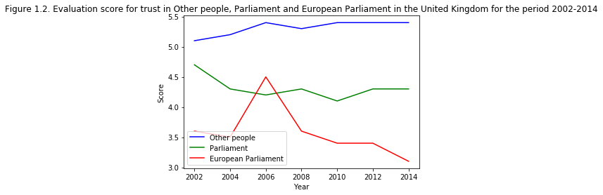

```python
plt.plot(dfGB.Periods, dfGB['Other people'], color='b')
plt.plot(dfGB.Periods, dfGB['Parliament'], color='g')
plt.plot(dfGB.Periods, dfGB['European Parliament'], color='r')
plt.xlabel('Year')
plt.ylabel('Score')
plt.legend()
plt.title('Figure 1.2. Evaluation score for trust in Other people, Parliament and European Parliament in the United Kingdom for the period 2002-2014')
plt.show()
```

Back to Answer and Discussion

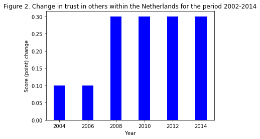

```
Countries
The Netherlands    0.1
The Netherlands    0.1
The Netherlands    0.3
The Netherlands    0.3
The Netherlands    0.3
Name: Other people, dtype: float64
```

```python
# Change in trust in others within the Netherlands for the period 2002-2014
df_diffNL = (df_trust['Other people'].loc[(df_trust.index=='The Netherlands') & (df_trust.Periods != '2002-01-01')] - df_trust['Other people'].loc[(df_trust.index=='The Netherlands') & (df_trust.Periods == '2002-01-01')])
plt.clf()
plt.bar([2004,2006,2008,2010,2012,2014],df_diffNL, color ='b')
plt.xlabel('Year')
plt.ylabel('Score (point) change')
plt.title('Figure 2. Change in trust in others within the Netherlands for the period 2002-2014')
plt.show()

df_diffNL.head()
```

Back to Answer and Discussion

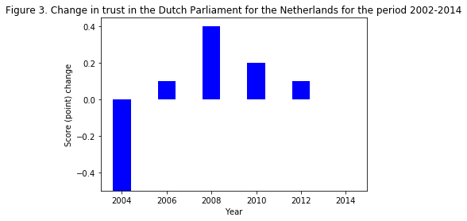

```
Countries
The Netherlands   -0.5
The Netherlands    0.1
The Netherlands    0.4
The Netherlands    0.2
The Netherlands    0.1
Name: Parliament, dtype: float64
```

```python
# Change in Evaluation score in trust in the Dutch Parliament (P), 2002-2014
df_diffNLP = (df_trust['Parliament'].loc[(df_trust.index=='The Netherlands') & (df_trust.Periods != '2002-01-01')] - df_trust['Parliament'].loc[(df_trust.index=='The Netherlands') & (df_trust.Periods == '2002-01-01')])
plt.clf()
plt.bar([2004,2006,2008,2010,2012,2014],df_diffNLP, color ='b')
plt.xlabel('Year')
plt.ylabel('Score (point) change')
plt.title('Figure 3. Change in trust in the Dutch Parliament for the Netherlands for the period 2002-2014')
plt.show()

df_diffNLP.head()
```

Back to Answer and Discussion

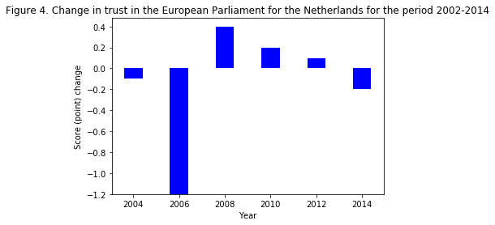

```
Countries
The Netherlands   -0.1
The Netherlands   -1.2
The Netherlands    0.4
The Netherlands    0.2
The Netherlands    0.1
Name: European Parliament, dtype: float64
```

```python
df_diffNLEP = (df_trust['European Parliament'].loc[(df_trust.index=='The Netherlands') & (df_trust.Periods != '2002-01-01')] - df_trust['European Parliament'].loc[(df_trust.index=='The Netherlands') & (df_trust.Periods == '2002-01-01')])
plt.clf()
plt.bar([2004,2006,2008,2010,2012,2014],df_diffNLEP, color ='b')
plt.xlabel('Year')
plt.ylabel('Score (point) change')
plt.title('Figure 4. Change in trust in the European Parliament for the Netherlands for the period 2002-2014')
plt.show()

df_diffNLEP.head()
```

Back to Answer and Discussion

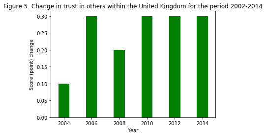

```
Countries
United Kingdom    0.1
United Kingdom    0.3
United Kingdom    0.2
United Kingdom    0.3
United Kingdom    0.3
Name: Other people, dtype: float64
```

```python
df_diffGB = (df_trust['Other people'].loc[(df_trust.index=='United Kingdom') & (df_trust.Periods != '2002-01-01')] - df_trust['Other people'].loc[(df_trust.index=='United Kingdom') & (df_trust.Periods == '2002-01-01')])
plt.clf()
plt.bar([2004,2006,2008,2010,2012,2014],df_diffGB, color ='g')
plt.xlabel('Year')
plt.ylabel('Score (point) change')
plt.title('Figure 5. Change in trust in others within the United Kingdom for the period 2002-2014')
plt.show()

df_diffGB.head()
```

Back to Answer and Discussion

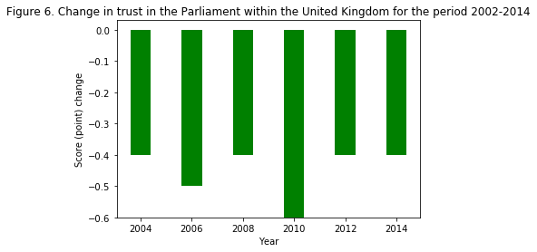

```
Countries
United Kingdom   -0.4
United Kingdom   -0.5
United Kingdom   -0.4
United Kingdom   -0.6
United Kingdom   -0.4
Name: Parliament, dtype: float64
```

```python
# Change in Evaluation score in trust in the UK Parliament (P), 2002-2014
df_diffGBP = (df_trust['Parliament'].loc[(df_trust.index=='United Kingdom') & (df_trust.Periods != '2002-01-01')] - df_trust['Parliament'].loc[(df_trust.index=='United Kingdom') & (df_trust.Periods == '2002-01-01')])
plt.clf()
plt.bar([2004,2006,2008,2010,2012,2014],df_diffGBP, color ='g')
plt.xlabel('Year')
plt.ylabel('Score (point) change')
plt.title('Figure 6. Change in trust in the Parliament within the United Kingdom for the period 2002-2014')
plt.show()

df_diffGBP.head()
```

Back to Answer and Discussion

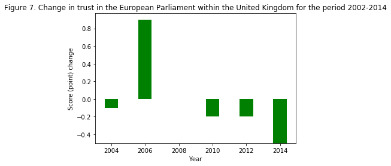

```
Countries
United Kingdom   -0.1
United Kingdom    0.9
United Kingdom    0.0
United Kingdom   -0.2
United Kingdom   -0.2
Name: European Parliament, dtype: float64
```

```python
# Change in Evaluation score in trust in the European Parliament (EP), 2002-2014
df_diffGBEP = (df_trust['European Parliament'].loc[(df_trust.index=='United Kingdom') & (df_trust.Periods != '2002-01-01')] - df_trust['European Parliament'].loc[(df_trust.index=='United Kingdom') & (df_trust.Periods == '2002-01-01')])
plt.clf()
plt.bar([2004,2006,2008,2010,2012,2014],df_diffGBEP, color ='g')
plt.xlabel('Year')
plt.ylabel('Score (point) change')
plt.title('Figure 7. Change in trust in the European Parliament within the United Kingdom for the period 2002-2014')
plt.show()

df_diffGBEP.head()
```

Back to Answer and Discussion

## Limitations and Further research

This paper uses a dataset wich is bounded by the availability of information due to political and historic events, which means that information was missing for some countries and some years. This resulted in shrinking the dataset to 13 countries. Our research question is linked to events which had global impact. This means, that our analysis cannot determine a causal relationship, but only investigate patterns that coinside with these events. We find it useful for further research to focus on a larger scale on trends in trust and investigate a causal relationship between changes in trust levels in the European Parliament for the United Kingdom and BrExit as well as one following from the financial crisis to lagged changes in trust.

## References

Bac, M. (2009). Generalized trust and wealth. International Review of Law and Economics, 29(1), 46-56.

CBS News (2017), https://www.youtube.com/watch?v=QKfZ4qUmEV0

European Social Survey and Statistics Netherlands (CBS StatLine) (2017) Trust in others, legal system and politics; European comparison, The Hague/Heerlen (http://statline.cbs.nl/Statweb/publication/?DM=SLEN&PA=80518eng&D1=a&D2=0&D3=0-11,13-22,24-30&D4=a&LA=EN&HDR=T&STB=G1,G2,G3&VW=T)

Roth, F. (2009). The effect of the financial crisis on systemic trust. Intereconomics, 44(4), 203-208.

Zak, P. J. (2003). Trust. Capco Institute Journal of Financial Transformation, 7, 13–21.